# **Exploratory Data Analysis (EDA)**

# **Ecommerce Customer Behavior Analysis**

## **1. Project Introduction**

In today’s data-driven business environment, understanding customer behavior is essential for making informed decisions related to marketing, inventory management, pricing, and customer retention. This project focuses on performing Exploratory Data Analysis (EDA) on a customer purchase behavior dataset to uncover meaningful patterns, trends, and insights.

The dataset contains information related to customer demographics, product details, purchase history, payment preferences, shipping choices, promotional usage, and customer feedback. However, like most real-world datasets, the raw data contained missing values, inconsistent formats, invalid entries, and noise that could negatively impact analysis.

To address these issues, a structured data cleaning and preparation process was implemented before conducting EDA. Once the data was cleaned, various statistical summaries and visualizations were used to analyze customer behavior and purchasing trends.

## **2. Project Objectives**

The main objectives of this project are:

- To clean and preprocess raw customer purchase data
- To handle missing, inconsistent, and invalid values effectively
- To understand customer demographics and buying behavior
- To analyze product performance and seasonal trends
- To study the impact of discounts, promo codes, and subscriptions
- To identify customer loyalty patterns
- To visualize insights using Matplotlib and Seaborn

## **3. Dataset Source**

The dataset used in this project was obtained from an external online source for educational and analytical purposes. It contains information related to customer demographics, product details, purchase history, payment methods, shipping preferences, promotional usage, and customer reviews.

**Dataset Link:**

[ https://www.opendatabay.com/data/consumer/ad9e2ab7-7559-4c89-af01-7d9df45b4255 ]

(OpenDataBay)

The dataset was downloaded in CSV format and initially contained missing values, inconsistent formats, and noisy entries, which were addressed during the data cleaning and preparation phase before performing Exploratory Data Analysis (EDA).

## **4. Scope of the Analysis**

This analysis is limited to exploratory insights and visualization-based observations. No predictive modeling is applied in this project. The results of this EDA can be further used as a foundation for advanced analytics or machine learning tasks such as customer segmentation, churn prediction, or sales forecasting.

## **5. Data Overview**

## 1. Objective of Data Cleaning

The goal of this data cleaning process is to prepare a high-quality, consistent, and reliable dataset for Exploratory Data Analysis (EDA). Raw datasets often contain missing values, inconsistent formats, invalid entries, and noise that can lead to incorrect insights. This documentation explains the cleaning strategy applied to each column and the reasoning behind it.

## 2. Dataset Overview

The dataset represents customer purchase behavior and includes:

- Customer identifiers
- Product details
- Demographic information
- Purchase history
- Payment and shipping details
- Customer feedback (ratings)

Both **categorical** and **numerical** variables required different cleaning strategies.

## 3. Column-wise Data Cleaning Analysis

### 3.1 Customer ID

**Issues Identified:**

- Mixed formats (alphanumeric values)
- Decimal representations
- Invalid or missing IDs

**Cleaning Actions:**

- Converted values to string format
- Extracted numeric component using regular expressions
- Converted to numeric datatype
- Dropped rows with invalid IDs
- Converted to nullable integer type

**Outcome:**

- All customer IDs are clean, numeric, and consistent
- Ensures reliable grouping and indexing

### 3.2 Item Purchased

**Issues Identified:**

- Case inconsistency (e.g., SHIRT, shirt, Shirt)
- Extra whitespaces
- Invalid text values (Nan, None, empty strings)

**Cleaning Actions:**

- Trimmed whitespace
- Standardized text to title case
- Replaced invalid values with NaN
- Filled missing values with "Unknown"
- Removed rows with unknown items

**Outcome:**

- Unique and standardized product names
- Accurate product-wise sales analysis

### 3.3 Size

**Issues Identified:**

- Mixed casing (s, M, xl)
- Missing and invalid size values

**Cleaning Actions:**

- Converted all sizes to uppercase
- Replaced invalid values with NaN
- Removed unknown sizes
- Retained only valid sizes (S, M, L, XL)

**Outcome:**

- Clean size categories
- Improved size-based trend analysis

### 3.4 Color

**Issues Identified:**

- Inconsistent formatting
- Missing values

**Cleaning Actions:**

- Removed extra spaces
- Standardized case formatting
- Replaced invalid values
- Removed unknown entries

**Outcome:**

- Accurate color-wise aggregation

### 3.5 Season

**Issues Identified:**

- Inconsistent labels
- Missing or unknown values

**Cleaning Actions:**

- Standardized text format
- Removed unknown seasons

**Outcome:**

- Reliable seasonal sales trends

### 3.6 Subscription Status

**Issues Identified:**

- Inconsistent categorical values
- Missing entries

**Cleaning Actions:**

- Normalized text format
- Removed unknown values

**Outcome:**

- Clean customer segmentation based on subscription

### 3.7 Shipping Type

**Issues Identified:**

- Inconsistent text values
- Missing information

**Cleaning Actions:**

- Standardized categories
- Removed unknown shipping types

**Outcome:**

- Improved shipping preference analysis

### 3.8 Discount Applied

**Issues Identified:**

- Invalid categorical entries
- Missing values

**Cleaning Actions:**

- Standardized categorical values
- Removed unknown entries

**Outcome:**

- Accurate discount effectiveness analysis

### 3.9 Promo Code Used

**Issues Identified:**

- Missing or invalid promo code values

**Cleaning Actions:**

- Standardized values
- Removed unknown entries

**Outcome:**

- Reliable promotional campaign analysis

### 3.10 Frequency of Purchases

**Issues Identified:**

- Inconsistent categorical labels
- Missing values

**Cleaning Actions:**

- Standardized text format
- Removed unknown entries

**Outcome:**

- Clear customer behavior segmentation

### 3.11 Gender

**Issues Identified:**

- Case inconsistency (male, Male, MALE)
- Missing values

**Cleaning Actions:**

- Standardized case formatting
- Replaced invalid values
- Removed unknown gender entries

**Outcome:**

- Clean demographic distribution

### 3.12 Category

**Issues Identified:**

- Duplicate category labels due to formatting

**Cleaning Actions:**

- Normalized text format
- Removed invalid entries

**Outcome:**

- Accurate product category analysis

### 3.13 Location

**Issues Identified:**

- Inconsistent location naming
- Missing values

**Cleaning Actions:**

- Standardized formatting
- Removed unknown locations

**Outcome:**

- Reliable geographic insights

### 3.14 Payment Method

**Issues Identified:**

- Inconsistent naming conventions
- Missing values

**Cleaning Actions:**

- Standardized payment method labels
- Removed unknown values

**Outcome:**

- Clear payment preference analysis

### 3.15 Age

**Issues Identified:**

- Missing values
- Decimal values

**Cleaning Actions:**

- Converted to numeric datatype
- Filled missing values using mean
- Rounded and converted to integer

**Outcome:**

- Realistic and analyzable age values

### 3.16 Purchase Amount (USD)

**Issues Identified:**

- Missing or non-numeric values

**Cleaning Actions:**

- Converted to numeric datatype
- Filled missing values using mean

**Outcome:**

- Accurate revenue and spending analysis

### 3.17 Previous Purchases

**Issues Identified:**

- Missing numeric values

**Cleaning Actions:**

- Converted to numeric datatype
- Filled missing values using mean

**Outcome:**

- Reliable customer loyalty metrics

### 3.18 Review Rating

**Issues Identified:**

- Invalid ratings outside accepted range
- Missing values

**Cleaning Actions:**

- Converted to numeric datatype
- Rounded to one decimal place
- Removed ratings greater than 5

**Outcome:**

- Trustworthy customer satisfaction analysis

## 7. Conclusion

This structured data cleaning process transformed raw, inconsistent data into a high-quality dataset suitable for Exploratory Data Analysis. The cleaned dataset ensures accurate visualizations, reliable statistical summaries, and meaningful business insights.

This preparation phase forms a strong foundation for further EDA, reporting, and machine learning tasks.

## **Actual Cleaning code:**

**Required libraries are imported for analysis and visualization**

```python
import pandas as pd
import numpy as np
import matplotlib.pyplot as plt
import seaborn as sns
import warnings
warnings.filterwarnings("ignore")
```

**Loads the dataset into Pandas.**

```python
data=pd.read_csv("Synthetic_Consumer_Behavior_Dataset.csv")
data
```

|  | Customer ID | Age | Gender | Item Purchased | Category | Purchase Amount (USD) | Location | Size | Color | Season | Review Rating | Subscription Status | Shipping Type | Discount Applied | Promo Code Used | Previous Purchases | Payment Method | Frequency of Purchases |
| --- | --- | --- | --- | --- | --- | --- | --- | --- | --- | --- | --- | --- | --- | --- | --- | --- | --- | --- |
| 0 | 2744.0 | 62.0 | Male | Blouse | Accessories | 67.0 | NaN | M | Red | Winter | 4.682923 | No | Free Shipping | Yes | No | 46.0 | Bank Transfer | Annually |
| 1 | 1659.0 | 22.0 | Male | Sandals | Accessories | 23.0 | Hawaii | S | White | Summer | 2.736382 | No | Standard | Yes | Yes | 34.0 | Venmo | Bi-Weekly |
| 2 | 2439.0 | 21.0 | Male | Scarf | Clothing | 77.0 | New Hampshire | NaN | Maroon | Fall | NaN | No | Store Pickup | No | Yes | 43.0 | NaN | Every 3 Months |
| 3 | 3407.0 | 27.0 | Male | Socks | Accessories | 26.0 | Nevada | L | Beige | Winter | 3.255002 | Yes | Free Shipping | Yes | No | 30.0 | Bank Transfer | Monthly |
| 4 | 3748.0 | 31.0 | Female | Shoes | Accessories | 55.0 | Idaho | M | NaN | NaN | 4.599148 | No | Standard | NaN | No | 6.0 | PayPal | Quarterly |
| ... | ... | ... | ... | ... | ... | ... | ... | ... | ... | ... | ... | ... | ... | ... | ... | ... | ... | ... |
| 101995 | 38991.4542144969 | 871.4232536619733 | FEMALE | JEANS | ACCESSORIES | 1187.4760827237806 | MONTANA | M | MAGENTA | FALL | 75.05340995997977 | NO | NEXT_DAY_AIR | NO | YES | 499.73894736842107 | VENMO | FORTNIGHTLY |
| 101996 | 38991.4542144969 | 871.4232536619733 | MALE | SANDALS | CLOTHING | 1187.4760827237806 | NORTH_CAROLINA | M | TEAL | SPRING | 75.05340995997977 | YES | NEXT_DAY_AIR | NO | YES | 499.73894736842107 | NAN | FORTNIGHTLY |
| 101997 | 38991.4542144969 | 871.4232536619733 | MALE | HAT | CLOTHING | 1187.4760827237806 | CALIFORNIA | L | GOLD | WINTER | 75.05340995997977 | NO | STORE_PICKUP | YES | NO | 499.73894736842107 | VENMO | QUARTERLY |
| 101998 | 38991.4542144969 | 871.4232536619733 | MALE | SKIRT | CLOTHING | 1187.4760827237806 | SOUTH_CAROLINA | S | GREEN | WINTER | 75.05340995997977 | NO | NEXT_DAY_AIR | YES | YES | 499.73894736842107 | CREDIT_CARD | BI-WEEKLY |
| 101999 | 38991.4542144969 | 871.4232536619733 | MALE | SOCKS | ACCESSORIES | 1187.4760827237806 | NEBRASKA | NAN | BLACK | WINTER | 75.05340995997977 | NO | 2-DAY_SHIPPING | NO | NO | 499.73894736842107 | CASH | MONTHLY |

102000 rows × 18 columns

**Displays first 5 rows to understand the data.**

```python
data.head()
```

|  | Customer ID | Age | Gender | Item Purchased | Category | Purchase Amount (USD) | Location | Size | Color | Season | Review Rating | Subscription Status | Shipping Type | Discount Applied | Promo Code Used | Previous Purchases | Payment Method | Frequency of Purchases |
| --- | --- | --- | --- | --- | --- | --- | --- | --- | --- | --- | --- | --- | --- | --- | --- | --- | --- | --- |
| 0 | 2744.0 | 62.0 | Male | Blouse | Accessories | 67.0 | NaN | M | Red | Winter | 4.682923 | No | Free Shipping | Yes | No | 46.0 | Bank Transfer | Annually |
| 1 | 1659.0 | 22.0 | Male | Sandals | Accessories | 23.0 | Hawaii | S | White | Summer | 2.736382 | No | Standard | Yes | Yes | 34.0 | Venmo | Bi-Weekly |
| 2 | 2439.0 | 21.0 | Male | Scarf | Clothing | 77.0 | New Hampshire | NaN | Maroon | Fall | NaN | No | Store Pickup | No | Yes | 43.0 | NaN | Every 3 Months |
| 3 | 3407.0 | 27.0 | Male | Socks | Accessories | 26.0 | Nevada | L | Beige | Winter | 3.255002 | Yes | Free Shipping | Yes | No | 30.0 | Bank Transfer | Monthly |
| 4 | 3748.0 | 31.0 | Female | Shoes | Accessories | 55.0 | Idaho | M | NaN | NaN | 4.599148 | No | Standard | NaN | No | 6.0 | PayPal | Quarterly |

**Shows dataset size (rows, columns)**

```python
data.shape
```

```
(102000, 18)
```

1. **Shows:**
- Column names
- Data types
- Missing (null) values
2. **We can clearly see that many numeric columns are stored as object, which is a data quality issue.**

```python
data.info()
```

```
<class 'pandas.core.frame.DataFrame'>
RangeIndex: 102000 entries, 0 to 101999
Data columns (total 18 columns):
 #   Column                  Non-Null Count  Dtype
---  ------                  --------------  -----
 0   Customer ID             97277 non-null  object
 1   Age                     97316 non-null  object
 2   Gender                  97332 non-null  object
 3   Item Purchased          97205 non-null  object
 4   Category                97273 non-null  object
 5   Purchase Amount (USD)   97261 non-null  object
 6   Location                97326 non-null  object
 7   Size                    97309 non-null  object
 8   Color                   97251 non-null  object
 9   Season                  97345 non-null  object
 10  Review Rating           97223 non-null  object
 11  Subscription Status     97398 non-null  object
 12  Shipping Type           97244 non-null  object
 13  Discount Applied        97227 non-null  object
 14  Promo Code Used         97139 non-null  object
 15  Previous Purchases      97245 non-null  object
 16  Payment Method          97268 non-null  object
 17  Frequency of Purchases  97147 non-null  object
dtypes: object(18)
memory usage: 14.0+ MB
```

```python
data.describe()
```

|  | Customer ID | Age | Gender | Item Purchased | Category | Purchase Amount (USD) | Location | Size | Color | Season | Review Rating | Subscription Status | Shipping Type | Discount Applied | Promo Code Used | Previous Purchases | Payment Method | Frequency of Purchases |
| --- | --- | --- | --- | --- | --- | --- | --- | --- | --- | --- | --- | --- | --- | --- | --- | --- | --- | --- |
| count | 97277 | 97316 | 97332 | 97205 | 97273 | 97261 | 97326 | 97309 | 97251 | 97345 | 97223 | 97398 | 97244 | 97227 | 97139 | 97245 | 97268 | 97147 |
| unique | 5286 | 107 | 5 | 51 | 9 | 163 | 101 | 5 | 51 | 9 | 90453 | 5 | 13 | 5 | 5 | 101 | 13 | 15 |
| top | 38991.4542144969 | 871.4232536619733 | Male | Blouse | Clothing | 1187.4760827237806 | Idaho | M | Olive | Spring | 75.05340995997977 | No | Free Shipping | No | No | 499.73894736842107 | PayPal | Every 3 Months |
| freq | 4733 | 4733 | 61486 | 4066 | 40274 | 4733 | 2208 | 43662 | 4152 | 23239 | 4733 | 66027 | 15904 | 51501 | 51393 | 4733 | 15836 | 13685 |

```python
data.isnull().sum()
```

|  | 0 |
| --- | --- |
| Customer ID | 4723 |
| Age | 4684 |
| Gender | 4668 |
| Item Purchased | 4795 |
| Category | 4727 |
| Purchase Amount (USD) | 4739 |
| Location | 4674 |
| Size | 4691 |
| Color | 4749 |
| Season | 4655 |
| Review Rating | 4777 |
| Subscription Status | 4602 |
| Shipping Type | 4756 |
| Discount Applied | 4773 |
| Promo Code Used | 4861 |
| Previous Purchases | 4755 |
| Payment Method | 4732 |
| Frequency of Purchases | 4853 |

**dtype:** int64

**You get the percentage of missing values in each column**

```python
data.isnull().sum()/len(data)*100
```

|  | 0 |
| --- | --- |
| Customer ID | 4.630392 |
| Age | 4.592157 |
| Gender | 4.576471 |
| Item Purchased | 4.700980 |
| Category | 4.634314 |
| Purchase Amount (USD) | 4.646078 |
| Location | 4.582353 |
| Size | 4.599020 |
| Color | 4.655882 |
| Season | 4.563725 |
| Review Rating | 4.683333 |
| Subscription Status | 4.511765 |
| Shipping Type | 4.662745 |
| Discount Applied | 4.679412 |
| Promo Code Used | 4.765686 |
| Previous Purchases | 4.661765 |
| Payment Method | 4.639216 |
| Frequency of Purchases | 4.757843 |

**dtype:** float64

**What to do when missing % is high or low**

| Missing % | Action |
| --- | --- |
| 0–5% | Drop rows or fill |
| 5–30% | Fill with mean/median/mode |
| 30–60% | Drop column or smart filling |
| >60% | Drop column |

**Checks how many duplicate rows exist.**

```python
data.duplicated().sum()
```

```
np.int64(1807)
```

**Removes duplicate rows.**

**Prevents biased analysis caused by repeated records.**

```python
data = data.drop_duplicates()
```

**Rename columns (make them cleaner)**

```python
data.columns = data.columns.str.strip().str.lower().str.replace(" ", "_")
```

- **Converts column names to:**

  lowercase

  no spaces
- **Makes columns easier to use (Purchase Amount (USD) → purchase_amount_(usd)).**

```python
data.sample(3)
```

|  | customer_id | age | gender | item_purchased | category | purchase_amount_(usd) | location | size | color | season | review_rating | subscription_status | shipping_type | discount_applied | promo_code_used | previous_purchases | payment_method | frequency_of_purchases |
| --- | --- | --- | --- | --- | --- | --- | --- | --- | --- | --- | --- | --- | --- | --- | --- | --- | --- | --- |
| 44039 | 751.0 | NaN | Male | Shorts | Clothing | 59.0 | Vermont | XL | Charcoal | Summer | 2.514774 | No | Store Pickup | Yes | Yes | 25.0 | Credit Card | Weekly |
| 52612 | error_1133.0 | error_27.0 | Male | Dress | Footwear | error_27.0 | Minnesota | M | NaN | Winter | error_2.612018 | No | Store Pickup | No | Yes | error_20.0 | NaN | Annually |
| 54452 | 2823.0 | 41.0 | Male | Jeans | Accessories | 33.0 | Washington | M | Teal | Spring | 4.165779 | No | Express | No | Yes | 2.0 | Cash | Quarterly |

# **Column wise Cleaning & Analysis**

```
1. Customer ID
```

The unique() function is used to see all distinct values present in a column.

It helps us understand data quality, consistency, and hidden issues before analysis or modeling.

```python
data['customer_id'].unique()
```

```
array(['2744.0', '1659.0', '2439.0', ..., 'error_2978.0', 'error_2669.0',
       'error_3696.0'], dtype=object)
```

```python
# Clean customer_id
data['customer_id'] = (
    data['customer_id']
    .astype(str)
    .str.extract(r'(\d+)')
)

data['customer_id'] = pd.to_numeric(data['customer_id'], errors='coerce')
data = data.dropna(subset=['customer_id'])
data['customer_id'] = data['customer_id'].astype('Int64')
```

- Convert to string: Ensures uniform processing, even if mixed types exist.
- Extract digits (\d+): Removes non-numeric characters and keeps only the numeric part of customer_id.
- Convert to numeric: Invalid or non-extractable values become NaN, making errors manageable.
- Drop missing IDs: Removes rows where customer_id couldn’t be cleaned.
- Cast to Int64: Stores IDs as integers while safely supporting missing values if needed.
- Result: customer_id becomes a clean, consistent, numeric identifier suitable for analysis and joins.

```
2.  Item Purchased | Size | Color | Season | Subscription Status | Shipping Type | Discount Applied | Promo Code Used |
    Frequency of Purchases | Gender | Category | Location | Payment Method
```

The unique() function is used to see all distinct values present in a column.

It helps us understand data quality, consistency, and hidden issues before analysis or modeling.

```python
data['item_purchased'].unique()
```

```
array(['Blouse', 'Sandals', 'Scarf', 'Socks', 'Shoes', 'Gloves', 'Belt',
       nan, 'T-shirt', 'Backpack', 'Dress', 'Coat', 'Sneakers', 'Skirt',
       'Pants', 'Hoodie', 'Sweater', 'Jewelry', 'Shirt', 'Handbag',
       'Shorts', 'Boots', 'Jeans', 'SHORTS', 'Sunglasses', 'Jacket',
       'GLOVES', 'Hat', 'BLOUSE', 'JEWELRY', 'SWEATER', 'DRESS', 'SKIRT',
       'JACKET', 'SCARF', 'JEANS', 'SANDALS', 'SHOES', 'NAN', 'BOOTS',
       'SUNGLASSES', 'BELT', 'SOCKS', 'HANDBAG', 'HAT', 'COAT', 'HOODIE',
       'T-SHIRT', 'BACKPACK', 'SNEAKERS', 'PANTS', 'SHIRT'], dtype=object)
```

```python
data['size'].unique()
```

```
array(['M', 'S', nan, 'L', 'XL', 'NAN'], dtype=object)
```

```python
data['color'].unique()
```

```
array(['Red', 'White', 'Maroon', 'Beige', nan, 'Silver', 'Black',
       'Lavender', 'Magenta', 'Brown', 'Teal', 'Cyan', 'Gray', 'Charcoal',
       'Blue', 'Orange', 'Olive', 'Indigo', 'Violet', 'Pink', 'Green',
       'Turquoise', 'Yellow', 'VIOLET', 'Gold', 'Peach', 'MAROON',
       'Purple', 'BLACK', 'GOLD', 'GRAY', 'RED', 'OLIVE', 'CYAN', 'TEAL',
       'CHARCOAL', 'YELLOW', 'PURPLE', 'GREEN', 'MAGENTA', 'LAVENDER',
       'BEIGE', 'BLUE', 'BROWN', 'PINK', 'WHITE', 'ORANGE', 'NAN',
       'TURQUOISE', 'SILVER', 'INDIGO', 'PEACH'], dtype=object)
```

```python
data['season'].unique()
```

```
array(['Winter', 'Summer', 'Fall', nan, 'Spring', 'SPRING', 'FALL',
       'SUMMER', 'WINTER', 'NAN'], dtype=object)
```

```python
data['subscription_status'].unique()
```

```
array(['No', 'Yes', nan, 'NO', 'YES', 'NAN'], dtype=object)
```

```python
data['shipping_type'].unique()
```

```
array(['Free Shipping', 'Standard', 'Store Pickup', '2-Day Shipping', nan,
       'Next Day Air', 'Express', 'NEXT_DAY_AIR', 'FREE_SHIPPING',
       'STORE_PICKUP', '2-DAY_SHIPPING', 'EXPRESS', 'STANDARD', 'NAN'],
      dtype=object)
```

```python
data['discount_applied'].unique()
```

```
array(['Yes', 'No', nan, 'YES', 'NO', 'NAN'], dtype=object)
```

```python
data['promo_code_used'].unique()
```

```
array(['No', 'Yes', nan, 'YES', 'NO', 'NAN'], dtype=object)
```

```python
categorical_cols = [
    'item_purchased', 'size', 'color', 'season',
    'subscription_status', 'shipping_type',
    'discount_applied', 'promo_code_used',
    'frequency_of_purchases', 'gender',
    'category', 'location', 'payment_method'
]

for col in categorical_cols:
    data[col] = data[col].astype(str).str.strip().str.title()
    data[col].replace(['Nan', 'Na', 'None', '', 'N/A'], np.nan, inplace=True)
    data[col].fillna('Unknown', inplace=True)
```

```python
data['size'] = data['size'].str.upper()

valid_sizes = ['S', 'M', 'L', 'XL']
data = data[data['size'].isin(valid_sizes)]
```

- Convert to uppercase: str.upper() standardizes size values (s, m, xl → S, M, XL) to avoid duplicate categories.
- Define valid sizes: Creates a clear rule set for acceptable size values (S, M, L, XL).
- Filter invalid entries: Keeps only rows with valid sizes and removes inconsistent or noisy data (e.g., XS, XXL, typos).
- Result: The size column becomes clean, standardized, and limited to meaningful categories, improving data quality for analysis and visualization.

```python
cols_remove_unknown = [
    'item_purchased', 'color', 'season',
    'subscription_status', 'shipping_type',
    'discount_applied', 'promo_code_used',
    'frequency_of_purchases', 'gender',
    'category', 'location', 'payment_method'
]

for col in cols_remove_unknown:
    data = data[data[col] != 'Unknown']
```

- Select key categorical columns: Identifies features where 'Unknown' values add noise and reduce analytical value.
- Row-level filtering: Removes rows where any of these columns contain 'Unknown', ensuring only fully informative records remain.
- Improve data reliability: Prevents ambiguous categories from affecting aggregations, comparisons, and visualizations.
- Note: This step may significantly reduce dataset size, so it’s best applied after initial EDA or when high data quality is required.
- Result: A more reliable, high-quality dataset with meaningful categorical values only.

```
3. Age | Purchase Amount USD | Previous Purchases | Review Rating
```

**Boxplot to Detect Outliers (Age)**

[figure not shown]

```python
plt.figure(figsize=(6,4))
sns.boxplot(y=data['age'])
plt.title("Boxplot for Age")
plt.ylabel("Age")
plt.show()
```

**Boxplot to Detect Outliers (Purchase Amount USD)**

[figure not shown]

```python
plt.figure(figsize=(6,4))
sns.boxplot(y=data['purchase_amount_(usd)'])
plt.title("Boxplot for Purchase Amount (Outlier Detection)")
plt.ylabel("Purchase Amount (USD)")
plt.show()
```

**The unique() function was used to inspect distinct values in each column and identify inconsistencies, invalid entries, and formatting issues before applying data cleaning operations.**

```python
data['age'].unique()
```

```
array(['22.0', '27.0', '61.0', '51.0', '36.0', '57.0', '41.0', '39.0',
       '65.0', '20.0', '55.0', '46.0', '52.0', '62.0', '63.0', nan,
       '48.0', '24.0', '54.0', '45.0', '44.0', '35.0', '58.0', '68.0',
       '50.0', '28.0', '23.0', '60.0', '56.0', '67.0', '64.0', '66.0',
       '871.4232536619733', '38.0', '40.0', '21.0', '47.0', '49.0',
       '31.0', 'error_871.4232536619733', '33.0', '53.0', '29.0', '69.0',
       '32.0', '37.0', '30.0', '59.0', '26.0', '42.0', '43.0', '19.0',
       '18.0', '34.0', '25.0', 'error_23.0', 'error_47.0', 'error_29.0',
       'error_27.0', 'error_63.0', 'error_44.0', 'error_62.0',
       'error_53.0', 'error_58.0', 'error_nan', 'error_34.0',
       'error_18.0', 'error_50.0', 'error_66.0', 'error_25.0',
       'error_65.0', 'error_51.0', 'error_55.0', 'error_52.0',
       'error_68.0', 'error_56.0', 'error_31.0', 'error_22.0',
       'error_37.0', 'error_41.0', 'error_67.0', 'error_60.0',
       'error_19.0', 'error_26.0', 'error_36.0', 'error_30.0',
       'error_32.0', 'error_21.0', 'error_59.0', 'error_49.0',
       'error_48.0', 'error_54.0', 'error_39.0', 'error_40.0',
       'error_38.0', 'error_57.0', 'error_43.0', 'error_64.0',
       'error_42.0', 'error_20.0', 'error_24.0', 'error_35.0',
       'error_33.0', 'error_28.0', 'error_46.0', 'error_61.0',
       'error_45.0', 'error_69.0'], dtype=object)
```

```python
data['purchase_amount_(usd)'].unique()
```

```
array(['23.0', '26.0', '76.0', '28.0', '84.0', '22.0', '31.0', '86.0',
       '39.0', '61.0', '72.0', '27.0', '87.0', '38.0', '73.0', '35.0',
       '83.0', '36.0', '65.0', '98.0', '34.0', '33.0', '44.0', '59.0',
       '58.0', '95.0', '43.0', '60.0', '63.0', '55.0', '21.0', '79.0',
       '71.0', '56.0', '78.0', '48.0', '50.0', nan, '1187.4760827237806',
       '41.0', '57.0', '42.0', '68.0', '45.0', '53.0', '94.0', '66.0',
       '82.0', '20.0', 'error_1187.4760827237806', '67.0', '40.0', '89.0',
       '29.0', '96.0', '85.0', '92.0', '37.0', '74.0', '81.0', '70.0',
       '24.0', '49.0', '64.0', '99.0', '90.0', '75.0', '32.0', '91.0',
       '30.0', '54.0', '80.0', '69.0', '97.0', '93.0', '51.0', '47.0',
       '88.0', 'error_53.0', '62.0', 'error_94.0', '25.0', '46.0',
       'error_21.0', '77.0', 'error_83.0', '52.0', 'error_31.0',
       'error_22.0', 'error_60.0', 'error_25.0', 'error_44.0',
       'error_66.0', 'error_56.0', 'error_54.0', 'error_59.0',
       'error_20.0', 'error_33.0', 'error_67.0', 'error_52.0',
       'error_28.0', 'error_87.0', 'error_42.0', 'error_70.0',
       'error_49.0', 'error_64.0', 'error_55.0', 'error_40.0',
       'error_41.0', 'error_82.0', 'error_68.0', 'error_79.0',
       'error_34.0', 'error_71.0', 'error_69.0', 'error_99.0',
       'error_nan', 'error_93.0', 'error_27.0', 'error_23.0',
       'error_72.0', 'error_46.0', 'error_57.0', 'error_26.0',
       'error_97.0', 'error_77.0', 'error_74.0', 'error_98.0',
       'error_24.0', 'error_73.0', 'error_38.0', 'error_86.0',
       'error_84.0', 'error_95.0', 'error_51.0', 'error_88.0',
       'error_85.0', 'error_50.0', 'error_61.0', 'error_63.0',
       'error_81.0', 'error_76.0', 'error_96.0', 'error_58.0',
       'error_91.0', 'error_80.0', 'error_48.0', 'error_30.0',
       'error_39.0', 'error_90.0', 'error_89.0', 'error_92.0',
       'error_65.0', 'error_62.0', 'error_36.0', 'error_35.0',
       'error_32.0', 'error_29.0', 'error_78.0', 'error_37.0',
       'error_43.0', 'error_45.0', 'error_47.0', 'error_75.0'],
      dtype=object)
```

```python
data['previous_purchases'].unique()
```

```
array(['34.0', '30.0', '40.0', '43.0', '32.0', '20.0', '28.0', '11.0',
       '18.0', '49.0', '29.0', '35.0', '37.0', '4.0', nan, '46.0', '36.0',
       '19.0', '14.0', '10.0', '31.0', '27.0', '1.0', '39.0', '42.0',
       '45.0', '21.0', '13.0', '23.0', '41.0', '47.0', '9.0',
       '499.73894736842107', '7.0', '25.0', '15.0', '3.0', '48.0', '6.0',
       'error_499.73894736842107', '26.0', '8.0', '5.0', '22.0', '2.0',
       '38.0', '24.0', '16.0', '17.0', '44.0', 'error_14.0', 'error_32.0',
       '33.0', '12.0', 'error_12.0', 'error_25.0', 'error_22.0',
       'error_26.0', 'error_16.0', 'error_30.0', 'error_45.0',
       'error_31.0', 'error_42.0', 'error_10.0', 'error_38.0',
       'error_13.0', 'error_nan', 'error_18.0', 'error_20.0',
       'error_15.0', 'error_41.0', 'error_47.0', 'error_49.0',
       'error_17.0', 'error_24.0', 'error_1.0', 'error_7.0', 'error_28.0',
       'error_48.0', 'error_21.0', 'error_9.0', 'error_37.0',
       'error_40.0', 'error_11.0', 'error_3.0', 'error_27.0',
       'error_34.0', 'error_2.0', 'error_19.0', 'error_33.0', 'error_8.0',
       'error_4.0', 'error_35.0', 'error_44.0', 'error_6.0', 'error_46.0',
       'error_5.0', 'error_39.0', 'error_43.0', 'error_23.0',
       'error_36.0', 'error_29.0'], dtype=object)
```

```python
data['review_rating'].unique()
```

```
array(['2.736382', '3.255002', '3.683842', ..., '2.988953', '4.520232',
       '3.376585'], dtype=object)
```

```python
numeric_cols = [
    'age', 'purchase_amount_(usd)',
    'previous_purchases', 'review_rating'
]

for col in numeric_cols:
    data[col] = pd.to_numeric(data[col], errors='coerce')
```

- Select numeric columns: Targets all features expected to contain numerical values for calculations and modeling.
- Convert to numeric: pd.to_numeric() enforces correct data types across columns.
- Handle invalid entries: Non-numeric values (e.g., text, symbols, typos) are automatically converted to NaN.
- Prepare for imputation/analysis: Converting errors to NaN makes it easier to handle missing values using mean, median, or other strategies.
- Result: All numeric columns are consistently typed, clean, and ready for statistical analysis and visualization

```python
data['age'].fillna(data['age'].mean(), inplace=True)
data['age'] = data['age'].round().astype(int)
```

- Impute missing values: Fills missing age values with the column mean to avoid data loss.
- Round values: Converts any decimal ages (from calculations or parsing) to whole numbers.
- Convert to integer: Ensures age is stored as an integer, which is more realistic and suitable for analysis.
- Note: Mean imputation may slightly reduce variability, but it’s acceptable for basic EDA and fresher-level projects.
- Result: The age column is complete, realistic, and clean for further analysis.

```python
for col in ['purchase_amount_(usd)', 'previous_purchases']:
    data[col].fillna(round(data[col].mean(), 2), inplace=True)
```

- Target numeric columns: Focuses on monetary and count-based features that are important for customer behavior analysis.
- Impute missing values with mean: Replaces NaN values using the column mean to retain all records.
- Round to 2 decimals: Ensures consistent numeric precision, especially for purchase amounts.
- Maintain data consistency: Prevents irregular decimal values caused by calculations or parsing issues.
- Note: Mean imputation can slightly smooth extreme values but is suitable for EDA and introductory projects.
- Result: Both columns are complete, clean, and ready for aggregation, visualization, and modelin

```python
data['review_rating'] = data['review_rating'].round(1)
data = data[data['review_rating'] <= 5]
```

- Round review ratings: Limits ratings to one decimal place for consistent and realistic scoring.
- Filter invalid values: Removes rows where review_rating exceeds the maximum valid limit (5).
- Improve data validity: Ensures ratings follow the expected scale, preventing skewed averages and misleading insights.
- Result: The review_rating column is standardized, realistic, and reliable for customer satisfaction analysis.

```python
# Reset Index Properly.
data.reset_index(drop=True, inplace=True)
```

- After filtering invalid records, the dataset index became non-continuous. The index was reset to ensure a clean and sequential index for further analysis and visualization.

```python
data
```

|  | customer_id | age | gender | item_purchased | category | purchase_amount_(usd) | location | size | color | season | review_rating | subscription_status | shipping_type | discount_applied | promo_code_used | previous_purchases | payment_method | frequency_of_purchases |
| --- | --- | --- | --- | --- | --- | --- | --- | --- | --- | --- | --- | --- | --- | --- | --- | --- | --- | --- |
| 0 | 1659 | 22 | Male | Sandals | Accessories | 23.0 | Hawaii | S | White | Summer | 2.7 | No | Standard | Yes | Yes | 34.0 | Venmo | Bi-Weekly |
| 1 | 3407 | 27 | Male | Socks | Accessories | 26.0 | Nevada | L | Beige | Winter | 3.3 | Yes | Free Shipping | Yes | No | 30.0 | Bank Transfer | Monthly |
| 2 | 3716 | 61 | Female | Gloves | Accessories | 76.0 | Kentucky | XL | Silver | Spring | 3.7 | Yes | Free Shipping | Yes | No | 40.0 | Bank Transfer | Annually |
| 3 | 2708 | 51 | Male | Belt | Accessories | 28.0 | Maine | XL | Black | Spring | 3.3 | No | 2-Day Shipping | No | No | 43.0 | Paypal | Quarterly |
| 4 | 3539 | 36 | Female | Dress | Accessories | 84.0 | Oklahoma | M | Magenta | Winter | 3.2 | No | Next Day Air | No | Yes | 32.0 | Cash | Annually |
| ... | ... | ... | ... | ... | ... | ... | ... | ... | ... | ... | ... | ... | ... | ... | ... | ... | ... | ... |
| 44245 | 135 | 33 | Female | Sneakers | Accessories | 70.0 | Oklahoma | L | Teal | Winter | 2.8 | Yes | 2-Day Shipping | Yes | No | 13.0 | Debit Card | Monthly |
| 44246 | 457 | 42 | Female | Backpack | Footwear | 33.0 | Delaware | L | Peach | Spring | 4.7 | No | Standard | No | No | 2.0 | Venmo | Annually |
| 44247 | 3857 | 49 | Male | Dress | Outerwear | 27.0 | Maryland | L | Blue | Fall | 3.0 | No | Store Pickup | No | No | 23.0 | Cash | Bi-Weekly |
| 44248 | 2502 | 71 | Male | Pants | Clothing | 98.0 | Hawaii | M | Green | Summer | 4.5 | Yes | Standard | Yes | No | 46.0 | Paypal | Monthly |
| 44249 | 2845 | 29 | Male | Skirt | Accessories | 94.0 | Indiana | S | Silver | Winter | 3.4 | Yes | 2-Day Shipping | Yes | No | 27.0 | Venmo | Fortnightly |

44250 rows × 18 columns

**Final missing value check**

```python
data.isnull().sum()
```

|  | 0 |
| --- | --- |
| customer_id | 0 |
| age | 0 |
| gender | 0 |
| item_purchased | 0 |
| category | 0 |
| purchase_amount_(usd) | 0 |
| location | 0 |
| size | 0 |
| color | 0 |
| season | 0 |
| review_rating | 0 |
| subscription_status | 0 |
| shipping_type | 0 |
| discount_applied | 0 |
| promo_code_used | 0 |
| previous_purchases | 0 |
| payment_method | 0 |
| frequency_of_purchases | 0 |

**dtype:** int64

```python
data.info()
```

```
<class 'pandas.core.frame.DataFrame'>
RangeIndex: 44250 entries, 0 to 44249
Data columns (total 18 columns):
 #   Column                  Non-Null Count  Dtype
---  ------                  --------------  -----
 0   customer_id             44250 non-null  Int64
 1   age                     44250 non-null  int64
 2   gender                  44250 non-null  object
 3   item_purchased          44250 non-null  object
 4   category                44250 non-null  object
 5   purchase_amount_(usd)   44250 non-null  float64
 6   location                44250 non-null  object
 7   size                    44250 non-null  object
 8   color                   44250 non-null  object
 9   season                  44250 non-null  object
 10  review_rating           44250 non-null  float64
 11  subscription_status     44250 non-null  object
 12  shipping_type           44250 non-null  object
 13  discount_applied        44250 non-null  object
 14  promo_code_used         44250 non-null  object
 15  previous_purchases      44250 non-null  float64
 16  payment_method          44250 non-null  object
 17  frequency_of_purchases  44250 non-null  object
dtypes: Int64(1), float64(3), int64(1), object(13)
memory usage: 6.1+ MB
```

# **Visualizations & Analysis**

**Basic Understanding:**

**1. What is the age distribution of customers?**

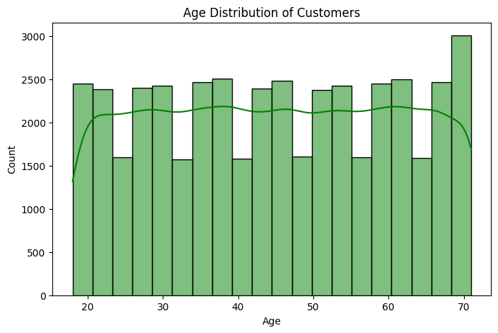

```python
from matplotlib.typing import LineStyleType
plt.figure(figsize=(8,5))
sns.histplot(data['age'], bins=20, kde=True,color='green')
plt.title("Age Distribution of Customers")
plt.xlabel("Age")
plt.ylabel("Count")
plt.show()
```

**Analysis:**

**Insight:**

- The customer base is age-diverse, allowing for broad, non-age-specific marketing and product strategies.
- **Risk:** Low risk if one age group’s engagement drops, since others balance it.

**2. Which gender has more purchases?**

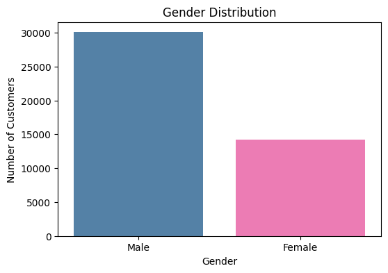

```python
plt.figure(figsize=(6,4))
sns.countplot(x='gender', data=data, palette={'Male': 'steelblue', 'Female': 'hotpink'})
plt.title("Gender Distribution")
plt.xlabel("Gender")
plt.ylabel("Number of Customers")
plt.show()
```

**Analysis**

- Male customers have a significantly higher number of purchases than female customers.
- The count for males is approximately twice that of females.
- This indicates a male-dominated customer base in terms of purchase volume.

**Insight:**

- Marketing and engagement strategies may be optimized by focusing on male customers while exploring opportunities to increase female customer participation.

**3. What are the most popular product categories?**

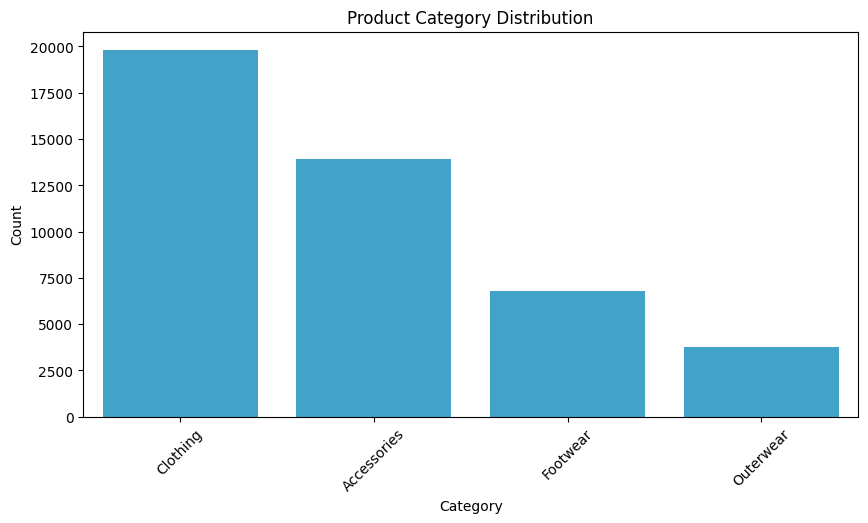

```python
plt.figure(figsize=(10,5))
sns.countplot(x='category', data=data, order=data['category'].value_counts().index,color='#2cacde')
plt.xticks(rotation=45)
plt.title("Product Category Distribution")
plt.xlabel("Category")
plt.ylabel("Count")
plt.show()
```

**Analysis**

- Clothing is the most popular category with the highest number of purchases.
- Accessories rank second, showing strong customer demand.
- Footwear has moderate popularity.
- Outerwear is the least purchased category.

**Insight:**

- Customer purchasing behavior is strongly inclined toward clothing and accessories, suggesting these categories are key revenue drivers, while outerwear may require targeted promotions or seasonal strategies.

**4. What is the average purchase amount?**

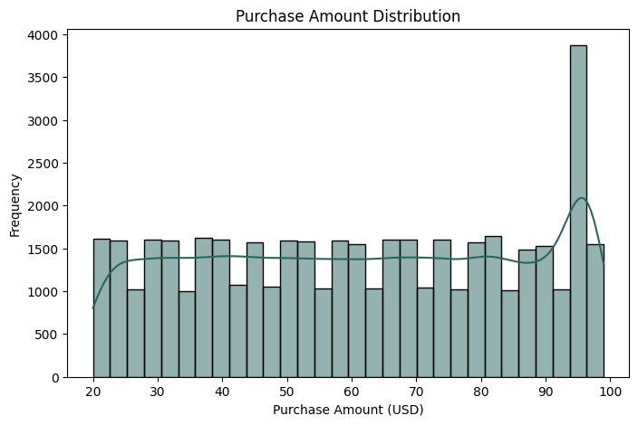

```python
plt.figure(figsize=(8,5))
sns.histplot(data['purchase_amount_(usd)'], bins=30, kde=True,color='#286662')
plt.title("Purchase Amount Distribution")
plt.xlabel("Purchase Amount (USD)")
plt.ylabel("Frequency")
plt.show()
```

**Analysis**

- Purchase amounts range approximately from $20 to $100.
- The distribution is fairly uniform, with a slight concentration toward the higher values.
- The average purchase amount appears to be around $60.

**Insight:**

- Customers typically spend a moderate amount per transaction, indicating consistent purchasing behavior with limited extreme values.

**Customer Behavior**

**5. Do customers with more previous purchases spend more?**

```python
data[['previous_purchases', 'purchase_amount_(usd)']].corr()
```

|  | previous_purchases | purchase_amount_(usd) |
| --- | --- | --- |
| previous_purchases | 1.000000 | 0.006782 |
| purchase_amount_(usd) | 0.006782 | 1.000000 |

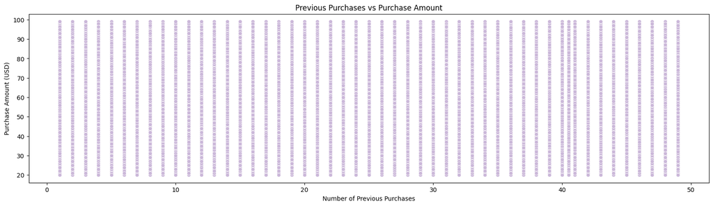

```python
plt.figure(figsize=(20, 5))
sns.scatterplot(
    data=data,
    x='previous_purchases',
    y='purchase_amount_(usd)',
    color='#cbb8d9'
)
plt.title('Previous Purchases vs Purchase Amount')
plt.xlabel('Number of Previous Purchases')
plt.ylabel('Purchase Amount (USD)')
plt.show()
```

**Analysis**

- The correlation between previous purchases and purchase amount is very weak (correlation ≈ 0.007).
- The scatter plot shows points widely dispersed with no clear upward or downward trend.
- Customers with more past purchases do not consistently spend more per transaction.

**Insight:**

- There is no significant relationship between customer loyalty (measured by previous purchases) and the amount spent in a single purchase. Spending behavior appears independent of purchase history.

**6. Which payment method is used the most?**

[figure not shown]

```python
plt.figure(figsize=(18,4))
sns.countplot(x='payment_method', data=data,color='#66282d')
plt.title("Payment Method Distribution")
plt.xlabel("Payment Method")
plt.ylabel("Count")
plt.show()
```

**Analysis**

- PayPal is the most frequently used payment method.
- Cash, Credit Card, Debit Card, and Venmo show similar and slightly lower usage levels.
- Bank Transfer is the least used method.
- Minor duplicate labels (e.g., Credit_Card, Debit_Card, Bank_Transfer) indicate inconsistent category naming in the dataset.

**Insight:**

- Digital payment methods dominate customer transactions, with PayPal leading. Data cleaning is recommended to standardize payment method labels before further analysis

**7. Which season has the highest number of purchases?**

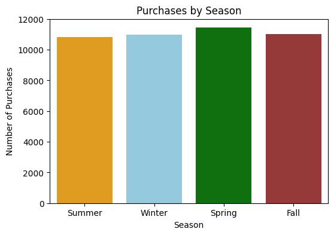

```python
plt.figure(figsize=(6,4))
sns.countplot(x='season', data=data, palette={
        'Summer': 'orange',
        'Winter': 'skyblue',
        'Spring': 'green',
        'Fall': 'brown'})
plt.title("Purchases by Season")
plt.xlabel("Season")
plt.ylabel("Number of Purchases")
plt.show()
```

**Analysis**

- Spring has the highest number of purchases.
- Winter and Fall show similar purchase volumes.
- Summer has slightly fewer purchases compared to other seasons.

**Insight:**

- Purchasing activity peaks in Spring, suggesting seasonal demand patterns that can be leveraged for targeted promotions and inventory planning.

**8. Does review rating affect purchase amount?**

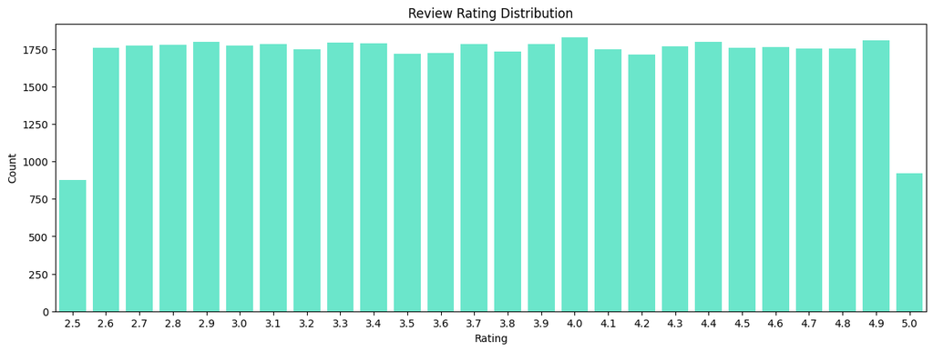

```python
plt.figure(figsize=(15,5))
sns.countplot(x='review_rating', data=data,color='#57fad7')
plt.title("Review Rating Distribution")
plt.xlabel("Rating")
plt.ylabel("Count")
plt.show()
```

**Analysis**

**Insight:**

**Location & Trends**

**9. Which locations have the highest number of customers?**

```python
top_10_locations = data['location'].value_counts().head(10)
```

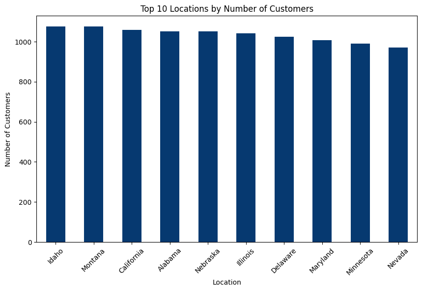

```python
plt.figure(figsize=(10, 6))
top_10_locations.plot(kind='bar',color='#063970')
plt.title('Top 10 Locations by Number of Customers')
plt.xlabel('Location')
plt.ylabel('Number of Customers')
plt.xticks(rotation=45)
plt.show()
```

**Analysis**

- Customer distribution across locations is fairly balanced.
- No single city overwhelmingly dominates the customer base.
- Top locations have similar customer counts, indicating wide geographic reach.

**Insight:**

- The business has a diverse and well-distributed regional customer base, reducing reliance on any single location.

**10.Are there differences in spending based on gender?**

```python
gender_spending=data.groupby('gender')['purchase_amount_(usd)'].mean()
gender_spending
```

| gender | purchase_amount_(usd) |
| --- | --- |
| Female | 61.750813 |
| Male | 60.981500 |

**dtype:** float64

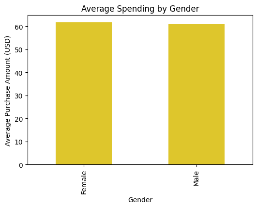

```python
plt.figure(figsize=(6, 4))
gender_spending.plot(kind='bar',color='#dec62c')
plt.title('Average Spending by Gender')
plt.xlabel('Gender')
plt.ylabel('Average Purchase Amount (USD)')
plt.show()
```

**Analysis**

- Female customers have a slightly higher average purchase amount than male customers.
- The difference in average spending between genders is minimal.
- Both genders spend around $60 per purchase on average.

**Insight:**

- While males make more purchases overall, spending per transaction is nearly equal across genders, indicating similar purchasing power.

## **Business Recommendations**

**Recommendation:**

**2️. Use Gender-Based Marketing Strategically**

- Launch gender-specific campaigns and product bundles.
- Promote premium products to the higher-spending gender segment.

**3️. Focus on High-Performing Product Categories**

**Insight:** A few product categories dominate total purchases.

**Recommendation:**

- Increase inventory and visibility for top-performing categories.
- Re-evaluate or improve low-performing categories through pricing or promotions.

**4️. Increase Average Order Value**

**Insight**: Most purchases are in a moderate price range, with a few high-value orders.

**Recommendation:**

- Introduce bundles, add-on products, and cross-selling strategies.
- Offer premium product options for high-value customers.

**5️. Strengthen Customer Loyalty Programs**

**Recommendation:**

- Implement reward points, membership tiers, or exclusive offers.
- Encourage repeat purchases through personalized discounts.

**6️. Optimize Payment Experience**

**Insight:** Digital payment methods are preferred by customers.

**Recommendation:**

- Ensure seamless checkout for popular digital payment methods.
- Partner with digital wallets for cashback or discount offers.

**7️. Plan Season-Based Promotions**

**Recommendation:**

- Schedule major sales events in high-performing seasons.
- Align inventory and marketing strategies with seasonal demand.

**8️. Leverage Customer Reviews**

**Recommendation:**

- Highlight top-rated products on the platform.
- Encourage satisfied customers to leave reviews via follow-ups or incentives.

**9️. Strengthen Regional Marketing**

**Insight:** Top 10 locations contribute the highest number of customers.

**Recommendation:**

- Run location-specific campaigns in high-demand regions.
- Improve delivery speed and logistics in key locations.

**10. Data Quality & Analytics Improvement**

**Insight:** Clean data enabled accurate and meaningful analysis.

**Recommendation:**

- Implement data validation rules at the data collection stage.
- Regularly monitor and clean data to maintain analytics accuracy.

## **Project Conclusion**

This project focused on performing a comprehensive **Exploratory Data Analysis (EDA)** on a customer purchase behavior dataset, with the objective of transforming raw, unstructured data into meaningful and actionable insights.

The first phase of the project involved **data cleaning and preprocessing**, where issues such as missing values, inconsistent data formats, invalid entries, and noisy categorical values were systematically addressed. Numerical columns were converted to appropriate data types, missing values were handled using statistical methods such as mean imputation, and invalid ranges were removed. Categorical variables were standardized by fixing case inconsistencies, trimming whitespace, and removing unknown or incorrect values. This step significantly improved the overall data quality and reliability of the dataset.

Overall, this project demonstrates the importance of a structured data cleaning process followed by effective EDA and visualization techniques. The cleaned and analyzed dataset provides a strong foundation for data-driven decision-making and can be further extended for advanced analytics or machine learning applications such as customer segmentation, churn prediction, or sales forecasting.